# Forschung zur Rezeption formativer Rückmeldungen von Unterrichtsqualität

## Inhaltlicher und organisatorischer Überblick

1. Verortung des Vortrags
2. Datengestützte Unterrichtsentwicklung
   - Rahmenmodell
3. Institutionalisierte Rückmeldesysteme
   - Funktion und Adressaten
   - Befunde zur Rezeption
4. Formative Rückmeldung für die Unterrichtsentwicklung
   - Grundidee
   - Exemplarische Umsetzung & Erste Befunde

Die interaktiven Folien können unter http://bit.ly/2gQTbSj und deren Quellcode

unter https://github.com/sammerk/vortrag-tue-w1 abgerufen werden

## Verortung des Vortrags

[interactive chart not shown]

## Datengestützte Unterrichtsentwicklung

## Rahmenmodell

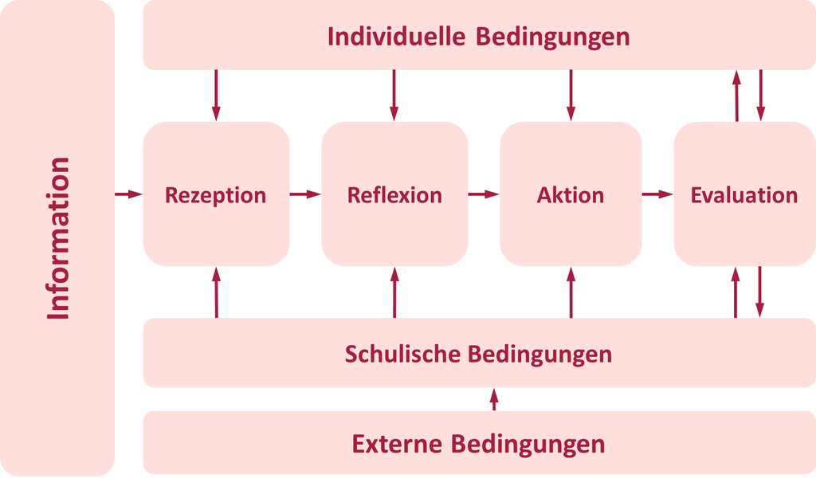

Abb. 2: Zyklenmodell "Von der Evaluation zur Innovation" (Helmke & Hosenfeld, 2005)

Folien: http://bit.ly/2gQTbSj - Quellcode: https://github.com/sammerk/vortrag-tue-w1

## Rahmenmodell

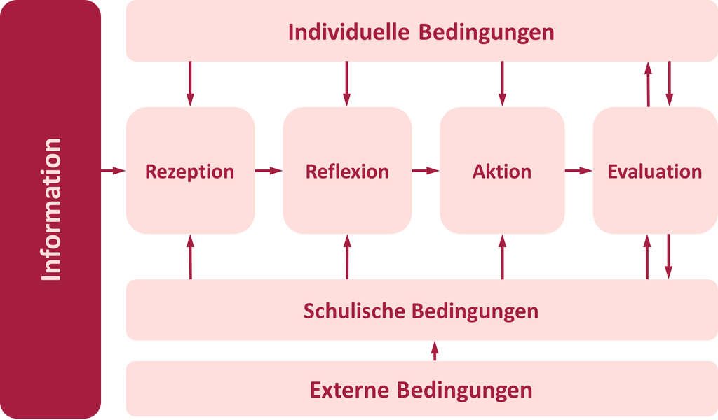

Abb. 2: Zyklenmodell "Von der Evaluation zur Innovation" (Helmke & Hosenfeld, 2005)

Folien: http://bit.ly/2gQTbSj - Quellcode: https://github.com/sammerk/vortrag-tue-w1

## Institutionalisierte Rückmeldesysteme

## Institutionalisierte Rückmeldesysteme

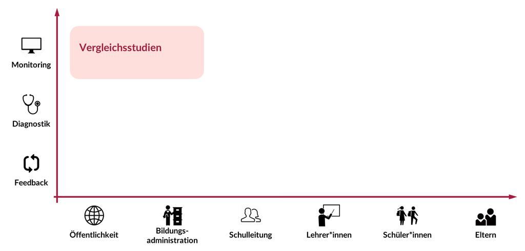

Abb. 3: Primäre Funktionen und Adressaten diverser Rückmeldesysteme (Altrichter & Maag Merki, 2016). Eigene Darstellung.

Folien: http://bit.ly/2gQTbSj - Quellcode: https://github.com/sammerk/vortrag-tue-w1

## Institutionalisierte Rückmeldesysteme

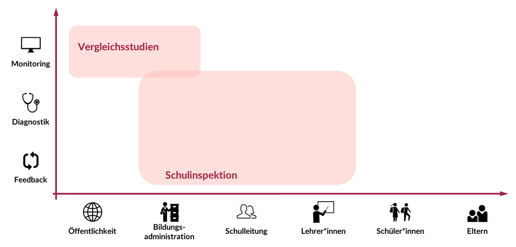

Abb. 3: Primäre Funktionen und Adressaten diverser Rückmeldesysteme (Altrichter & Maag Merki, 2016). Eigene Darstellung.

Folien: http://bit.ly/2gQTbSj - Quellcode: https://github.com/sammerk/vortrag-tue-w1

## Institutionalisierte Rückmeldesysteme

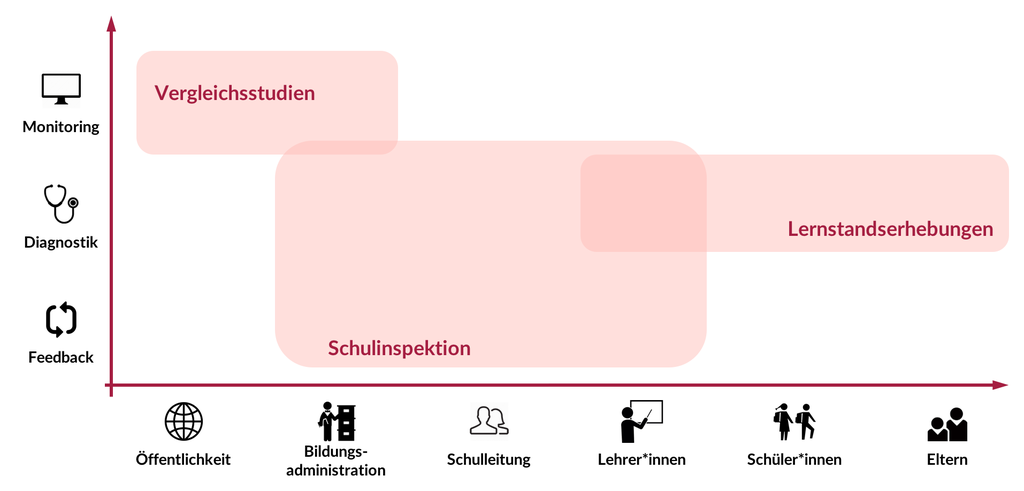

Abb. 3: Primäre Funktionen und Adressaten diverser Rückmeldesysteme (Altrichter & Maag Merki, 2016). Eigene Darstellung.

Folien: http://bit.ly/2gQTbSj - Quellcode: https://github.com/sammerk/vortrag-tue-w1

## Rückmeldesysteme für die Akteure?

## Rückmeldesysteme für die Akteure?

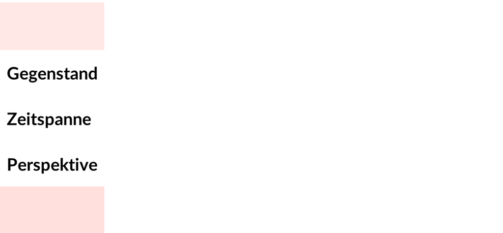

Tab. 1: Nach Gärtner (2013) und Maier (2008). Eigene Darstellung.

## Rückmeldesysteme für die Akteure?

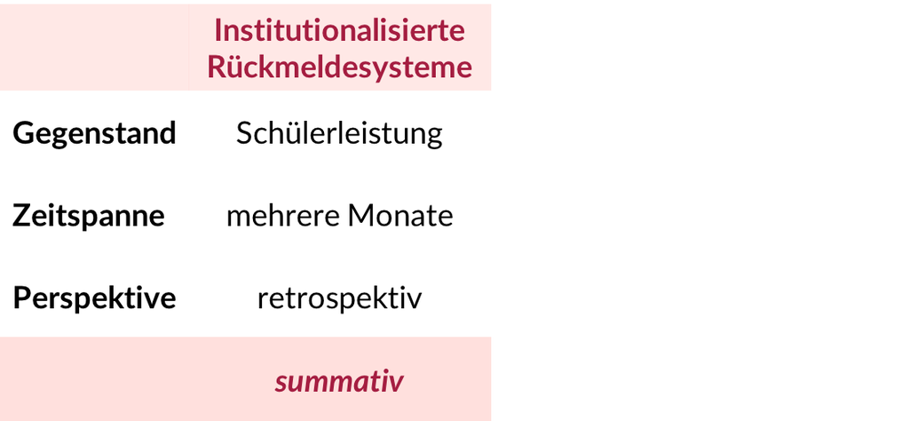

Tab. 1: Nach Gärtner (2013) und Maier (2008). Eigene Darstellung.

## Rückmeldesysteme für die Akteure?

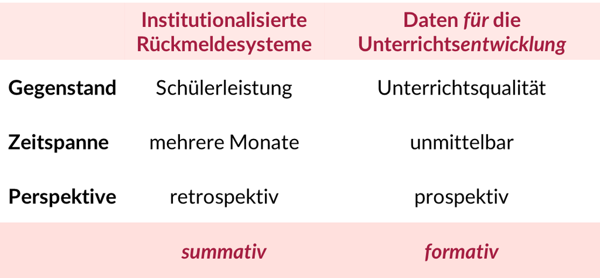

Tab. 1: Nach Gärtner (2013) und Maier (2008). Eigene Darstellung.

## Befunde zur Rezeption und Nutzung

- **Summative Leistungsrückmeldung**
  - breite Rezeption (Dedering, 2011, Schneewind, 2007)
  - geringe Nutzung zur Unterrichtsentwicklung (Maier, 2008)
  - externale Kausalattribution (Hellrung & Hartig, 2013)
- **Formative Rückmeldungen zur Unterrichtsqualität**
  - hohe intrinsische Motivation zur Rezeption (Gaertner, 2014)
  - konstruktive Nutzung zur Unterrichtsentwicklung (Gaertner, 2014)
  - positive Wirkung auf Unterrichtsentwicklung (moderiert durch Individuelle Bedingungen) (Ditton & Arnoldt, 2004)
- Methodische Probleme: Selbstauskünfte, hohe Selektivität, nichtexperimentelle/One-Shot-Studien, unklare abhängige Konstrukte, …

## Rückmeldungen für die Unterrichtsentwicklung

## Grundidee

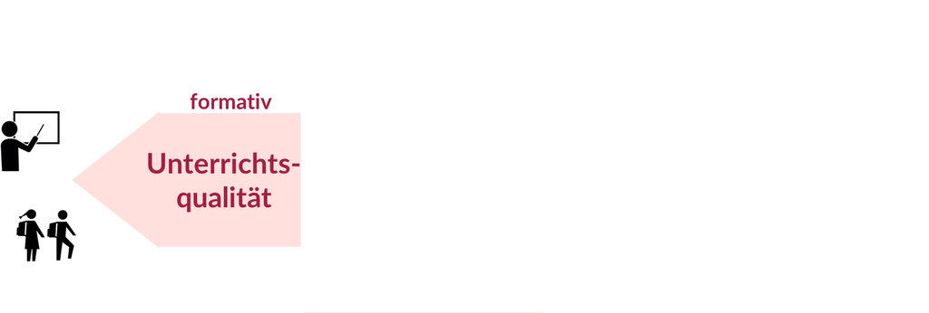

## Grundidee

[figure not shown]

## Grundidee

[figure not shown]

## Exemplarische Umsetzung

- Anfrage einer großen Nachhilfeschule (\(N_{Level_1}\) = 9730 Schüler*innen; \(N_{Level_2}\) = 189 Lehrer*innen = Studierende) nach Qualitätssicherung
- Implementation regelmäßiger Evaluation der Unterrichtsqualität (SEEQ, Marsh, 1982, Details siehe Anhang)
- Entwicklung eines Onlineportals zur
  - zeitnahen Bereitstellung formativen Feedbacks
  - Aufzeichnung des Rezeptionsverhaltens (Logdaten)

## Das Onlineportal (einige Aspekte)

- Inferenzniveau (Rindermann, 1999)
  - Einzelantworten, Skalenwerte, Freitextantworten

[figure not shown]

## Das Onlineportal (einige Aspekte)

- Bezugsnorm (Rheinberg, 2001)
  - kriteriale Norm, soziale Bezugsnorm, intraindividuelle Bezugsnorm

[figure not shown]

## Erste Befunde zum Rezeptionsverhalten

## Verweildauer und Informativität

[interactive chart not shown]

## Grundidee in diversen Kontexten

[figure not shown]

## Herzlichen Dank!

## Anhang I

## Potentielle (experimentelle) Forschung

- **Gestaltung** formativer Rückmeldungen
  - Cues, Interaktivität, Zeitpunkt
- **Rezeption** formativer Rückmeldungen von Unterrichtsqualität
  - Effekte der Gestaltung: Inferenzniveau der Daten, Bezugsnorm, Gegenstand, Skalierung, statistische Kennwerte
  - Effekte individueller, schulischer und außerschulischer Bedingungen
- **Interventionen** zur Förderung korrekter und günstiger Rezeption
  - Datenkompetenz, Bezugsnormorientierung

    Hohe Synergie möglich: Daten sind vorhanden, Feld ist interessiert, Probanden werden entlastet, Ergebnisse unmittelbar praxisrelevant

## Anhang II

## Psychometrie SEEQ

[interactive chart not shown]

## Skalenhandbuch Lehrerfragebogen

[interactive chart not shown]

## Literatur

Altrichter, H. & Maag Merki, K. (Hrsg.). (2016). *Handbuch Neue Steuerung im Schulsystem* (Educational governance) (2. Auflage). Wiesbaden: Springer VS.

Dedering, K. (2011). Hat Feedback eine positive Wirkung? Zur Verarbeitung extern erhobener Leistungsdaten in Schulen. *Unterrichtswissenschaft*, *39* (1), 63–83.

Ditton, H. & Arnoldt, B. (2004). Schülerbefragungen zum Fachunterricht - Feedback an Lehrkräfte. *Empirische Pädagogik*, *18* (1), 115–139. gedruckt,.

Gaertner, H. (2014). Effects of student feedback as a method of self-evaluating the quality of teaching. *Studies in Educational Evaluation*, *42*, 91–99. Elsevier Ltd. doi:10.1016/j.stueduc.2014.04.003

Gärtner, H. (2013). Praxis und Verhältnis interner und externer Evaluation im Schulsystem im internationalen Vergleich. *Zeitschrift für Erziehungswissenschaft*, *16* (4), 693–712. online; gedruckt,. Verfügbar unter: http://dx.doi.org/10.1007/s11618-013-0444-7

Hellrung, K. & Hartig, J. (2013). Understanding and using feedback – A review of empirical studies concerning feedback from external evaluations to teachers. *Educational Research Review*, *9*, 174–190. doi:10.1016/j.edurev.2012.09.001

Helmke, A. & Hosenfeld, I. (2005). Standardbezogene Unterrichtsevaluation. In G. Brägger, B. Bucher & N. Landwehr (Hrsg.), *Schlüsselfragen zur externen Schulevaluation* (S. 127–151). Bern: h.e.p.-Verlag.

Maier, U. (2008). Vergleichsarbeiten im vergleich - Akzeptanz und wahrgenommener nutzen standardbasierter leistungsmessungen in Baden-Württemberg und Thüringen. *Zeitschrift für Erziehungswissenschaft*, *11* (3), 453–474. doi:10.1007/s11618-008-0036-0

Marsh, H.W. (1982). Seeq: A reliable, valid, and useful instrument for collecting students’ evaluations of university teaching. *British Journal of Educational Psychology*, *52* (1), 77–95. doi:10.1111/j.2044-8279.1982.tb02505.x

Rheinberg, F. (2001). Bezugsnormen und schulische Leistungsbeurteilung. In F. Weinert (Hrsg.), *Leistungsmessungen in Schulen* (S. 59–71). Weinheim: Belz.

Rindermann, H. (1999). Bedingungs-und Effektvariablen in der Lehrevaluationsforschung: Konzeption und Prüfung des Münchner multifaktoriellen Modells der Lehrveranstaltungsqualität. *Unterrichtswissenschaft*, *27* (4), 357–380.

Schneewind, J. (2007). Erfahrungen mit Ergebnisrückmeldungen im Projekt BeLesen - Ergebnisse der Interviewstudie. *Empirische Pädagogik*, *21*.